# Predictive Policing - Geospatial Risk Modeling

Johnathan Clementi

10/29/2021

# Introduction

This workflow is primarily designed for city or county police, sheriff, and/or 311 departments. Traditionally, these departments have either used rudimentary methods of predicting where crimes or disturbances will occur or not used any predictions at all. The methods of prediction usually entail hot-spot mapping through kernel density analysis. In this workflow, we will try to build a model using regression techniques to predict where crimes will occur, and thus allow for more effective and efficient deployment of city or county resources.

We will build the model using data from 2017, test its accuracy using cross validation techniques, and then determine if it generalizable to future scenarios by testing it using data form 2018. We chose to model 311 Complaints about graffiti for its possible issues with selection bias. Said differently, what is classified as graffiti and what is classified as art is subjective. Therefore, we would expect to see some spatial clustering of graffiti complaints based on outside factors. This is what we will try to account for in our model.

# Methods

### Data Retrieval and Cleaning

These data come from OpenDataDC and a github repository maintained by David Blackman (DC Neighborhoods).

```r
crs <- 'ESRI:102285' #StatePlane Maryland

# Overall DC Boundary
DCBoundary <-
  st_read("https://opendata.arcgis.com/datasets/7241f6d500b44288ad983f0942b39663_10.geojson") %>%
  st_transform(crs)

# DC Neighborhoods from github open data
## Used in LOOCV
neighborhoods <-
  st_read("https://raw.githubusercontent.com/blackmad/neighborhoods/master/washington.geojson") %>%
  st_transform(crs)

# Police Districts (7 districts) (larger spatial unit)
policeDistricts <-
  st_read("https://opendata.arcgis.com/datasets/d2a63e5246ff41bdaca8ea9be95c8a4b_9.geojson") %>%
  st_transform(crs) %>%
  dplyr::select(District = DISTRICT) %>%
  mutate(District = as.character(District))

# Each police district has about 3 Sectors (smaller spatial unit)
policeSectors <-
  st_read("https://opendata.arcgis.com/datasets/6ac17c2ff8cc4e20b3768dd1b98adf7a_23.geojson") %>%
  st_transform(crs) %>%
  dplyr::select(District = NAME)

# Format police sectors in usable way
policeSectors$District <- paste0("0", str_replace(policeSectors$District, "D", "0"))


bothPoliceUnits <- rbind(mutate(policeDistricts, Legend = "Police Districts"),
                         mutate(policeSectors, Legend = "Police Sectors"))


# DC 311 Complaints
DC311 <-
  st_read("https://opendata.arcgis.com/datasets/19905e2b0e1140ec9ce8437776feb595_8.geojson") %>%
  st_transform(crs)  %>%
  dplyr::select(-c("INSPECTIONFLAG", "INSPECTIONDATE", "INSPECTORNAME"))

DC311Vars <- data.frame(table(DC311$SERVICECODEDESCRIPTION))

# Pull graffiti from overall 311 data
graffiti <- DC311 %>%
  filter(grepl("Graffiti", SERVICECODEDESCRIPTION)) %>%
  mutate(Count = 1) %>%
  dplyr::select(Description = SERVICECODEDESCRIPTION, Count)
```

### Visualizing Distribution of Graffiti

In the figure below, we have mapped both the raw locations of all 311 Graffiti removal complaints and the density of complaints across the Washington, DC for 2017.

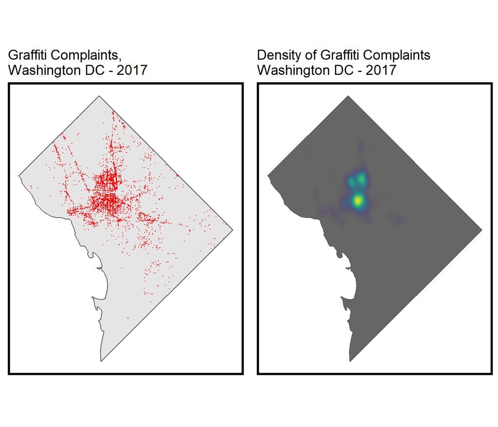

```r
grid.arrange(ncol=2,
ggplot() +
  geom_sf(data = DCBoundary) +
  geom_sf(data = graffiti, colour="red", size=0.1, show.legend = "point") +
  labs(title= "Graffiti Complaints,\nWashington DC - 2017") +
  mapTheme(title_size = 14),

ggplot() +
  geom_sf(data = DCBoundary, fill = "grey40") +
  stat_density2d(data = data.frame(st_coordinates(graffiti)),
                 aes(X, Y, fill = ..level.., alpha = ..level..),
                 size = 0.01, bins = 40, geom = 'polygon') +
  scale_fill_viridis() +
  scale_alpha(range = c(0.00, 0.35), guide = FALSE) +
  labs(title = "Density of Graffiti Complaints\nWashington DC - 2017") +
  mapTheme(title_size = 14) + theme(legend.position = "none"))
```

### Areas of Analysis

For hotspot analysis, it is useful to first create a grid cell lattice known as a `fishnet`. The fishnet is useful in smoothly visualizing how phenomena varies across space. In the code and figure below, we have created the fishnet for Washington, DC and calculated the number of graffiti complaints that occurred within each fishnet cell in 2017.

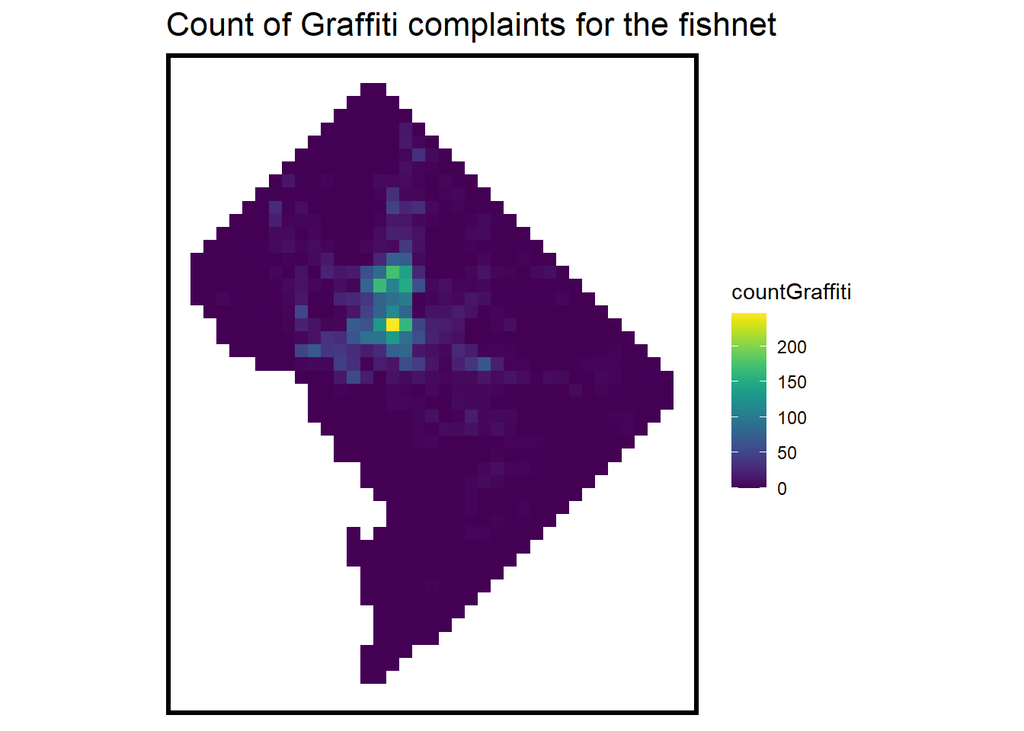

```r
## using {sf} to create the grid
## Note the `.[DCBoundary] %>% ` line. This is needed to clip the grid to our data

fishnet <-
  st_make_grid(DCBoundary,
               cellsize = 500,
               square = TRUE) %>%
  .[DCBoundary] %>%
  st_sf() %>%
  mutate(uniqueID = rownames(.))


crime_net <-
  dplyr::select(graffiti) %>%
  mutate(countGraffiti = 1) %>%
  aggregate(., fishnet, sum) %>%
  mutate(countGraffiti = replace_na(countGraffiti, 0),
         uniqueID = rownames(.),
         cvID = sample(round(nrow(fishnet) / 24),
                       size=nrow(fishnet), replace = TRUE))

ggplot() +
  geom_sf(data = crime_net, aes(fill = countGraffiti), color = NA) +
  scale_fill_viridis() +
  labs(title = "Count of Graffiti complaints for the fishnet") +
  mapTheme()
```

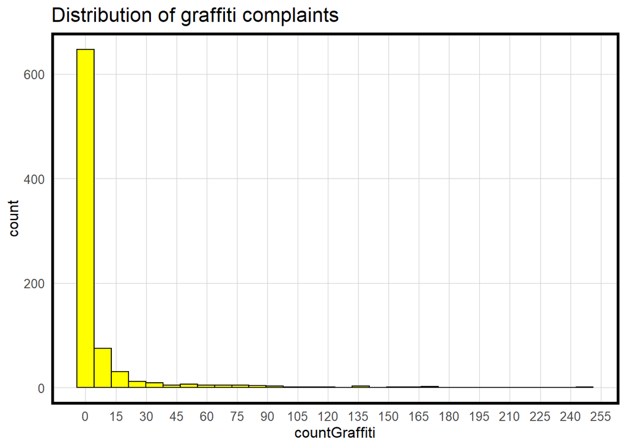

```r
# Distribution of Graffiti Complaints across fishnet
ggplot(data = crime_net, aes(countGraffiti))+
  geom_histogram(bins = 30, color = 'black', fill = "yellow") +
  scale_x_continuous(breaks = seq(0, 275, by = 15)) +
  labs(title = 'Distribution of graffiti complaints') +
  plotTheme()
```

## Modeling Spatial Features

### Predictor variables

The data retrieved below will be used as predictor variables for building the model to predict the location of graffiti complaints.

```r
# Abandoned cars (includes both public & private land)
abandonedCars <- DC311 %>%
  filter(grepl("Abandoned Vehicle", SERVICECODEDESCRIPTION)) %>%
  mutate(Legend = "Abandoned_Car", Count = 1) %>%
  dplyr::select(Legend, Count)

# Alley Cleaning
alleyCleaningReq <- DC311 %>%
  filter(grepl("Alley Cleaning", SERVICECODEDESCRIPTION)) %>%
  mutate(Legend = "AlleyCleaningReq", Count = 1) %>%
  dplyr::select(Legend, Count)

# Pull Illegal Dumping from overall 311 data
Illegal_Dumping <- DC311 %>%
  filter(grepl("Illegal Dumping", SERVICECODEDESCRIPTION)) %>%
  mutate(Legend = "Illegal_Dumping", Count = 1) %>%
  dplyr::select(Legend, Count)

# Maybe drunk people are more likely to tag?
liquourLicenses <- st_read("https://opendata.arcgis.com/datasets/cabe9dcef0b344518c7fae1a3def7de1_5.geojson") %>%
  st_transform(crs) %>%
  mutate(Legend = "liquourLicenses", Count = 1) %>%
  dplyr::select(Legend, Count)

# Metro stations
metroStops <- st_read("https://opendata.arcgis.com/datasets/54018b7f06b943f2af278bbe415df1de_52.geojson") %>%
    st_transform(crs) %>%
  mutate(Legend = "metroStops", Count = 1) %>%
  dplyr::select(Legend, Count)

# 311 complaints regarding streetlight outages
streetlightsOut <- DC311%>%
  filter(grepl("Streetlight", SERVICECODEDESCRIPTION)) %>%
  mutate(Legend = "streetlightsOut", Count = 1) %>%
  dplyr::select(Legend, Count)

# Major crimes
thefts <- st_read("https://opendata.arcgis.com/datasets/6af5cb8dc38e4bcbac8168b27ee104aa_38.geojson") %>%
  st_transform(crs) %>%
    filter(grepl('THEFT',OFFENSE)) %>%
    mutate(Legend = "thefts", Count = 1) %>%
    dplyr::select(Legend, Count)


# create single dataset for all predictors
allPredictors <- rbind(alleyCleaningReq, Illegal_Dumping, liquourLicenses, metroStops, streetlightsOut, thefts)
```

#### Predictor variables visualized

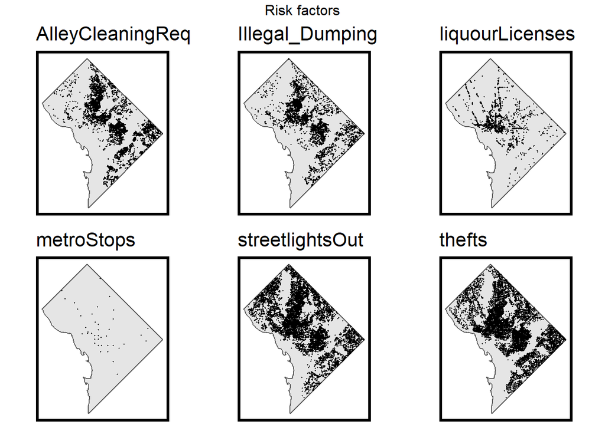

```r
vars <- unique(allPredictors$Legend)
mapList <- list()

for(i in vars){
  mapList[[i]] <-
    ggplot() +
      geom_sf(data = DCBoundary) +
      geom_sf(data = filter(allPredictors, Legend == i), size = 0.2) +
      labs(title=i) +
      mapTheme()}

do.call(grid.arrange,c(mapList, ncol = 3, top = "Risk factors"))
```

#### Merging predictors and the fishnet

Much like we aggregated the dependent variable (graffiti complaints) by each fishnet cell, we also aggregate the predictor variables. The code below completes that task.

```r
vars_net <- allPredictors %>%
  st_join(., fishnet, join=st_within) %>%
  st_drop_geometry() %>%
  group_by(uniqueID, Legend) %>%
  summarize(count = n()) %>%
  full_join(fishnet, by = "uniqueID") %>%
  spread(Legend, count, fill=0) %>%
  st_sf() %>%
  dplyr::select(-`<NA>`) %>%
  na.omit() %>%
  ungroup()

# vars_net <- allPredictors %>%
#   spatially join allPredictors points to the fishnet polygon they are within %>%
#   drop the geometry attribute %>%
#   group_by each cells ID and the name of the feature %>%
#   summarize count the number of each point per grid cell %>%
#   join that summary back to spatial fishnet by cell ID %>%
#   "spread" from long to wide format and make column of our point count %>%
#   tell R that this should be an sf object %>%
#   remove a fussy column that appears b/c of NA %>%
#   get rid of rows with an NA in any column %>%
#   remove grouping so you are not tripped up later
```

### Nearest Neighbor Features

We then calculate the average distance to the `k` number of nearest neighbors for each predictor variable to the centroid of the fishnet cell. These values are then visualized.

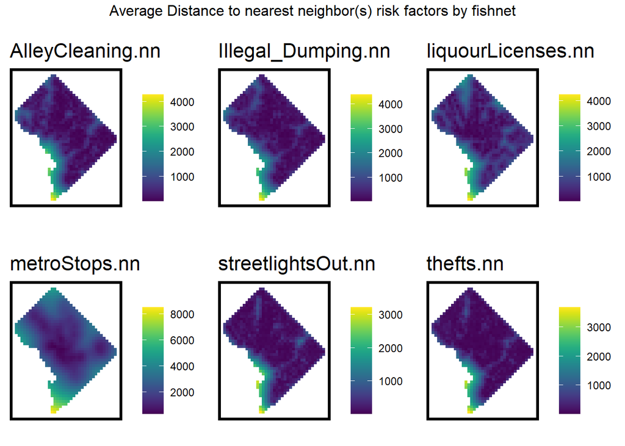

```r
# convinience to reduce length of function names.
st_c    <- st_coordinates
st_coid <- st_centroid

# Get coordinates of fishnet centroids
netCentroidCoords <- st_c(st_coid(vars_net))

# Get coordinates for k-nearest neighbor functions below
accoords <- st_c(abandonedCars)
alcoords <- st_c(alleyCleaningReq)
idcoords <- st_c(Illegal_Dumping)
lqcoords <- st_c(liquourLicenses)
mscoords <- st_c(metroStops)
slcoords <- st_c(streetlightsOut)
tcoords <- st_c(thefts)

# Define number of nearest neighbors to look for
k = 3


## create NN from abandoned cars
vars_net <- vars_net %>%
    mutate(#Abandoned_Cars.nn = nn_function(netCentroidCoords, accoords, k),
           AlleyCleaning.nn = nn_function(netCentroidCoords, alcoords, k),
           Illegal_Dumping.nn = nn_function(netCentroidCoords, idcoords, k),
           liquourLicenses.nn = nn_function(netCentroidCoords, lqcoords, k),
           metroStops.nn = nn_function(netCentroidCoords, mscoords, k),
           streetlightsOut.nn = nn_function(netCentroidCoords, slcoords, k),
           thefts.nn = nn_function(netCentroidCoords, tcoords, k)
          )

## Visualize the NN feature
vars_net.long.nn <-
  dplyr::select(vars_net, ends_with(".nn")) %>%
    gather(Variable, value, -geometry)

vars <- unique(vars_net.long.nn$Variable)
mapList <- list()

for(i in vars){
  mapList[[i]] <-
    ggplot() +
      geom_sf(data = filter(vars_net.long.nn, Variable == i), aes(fill=value), colour=NA) +
      scale_fill_viridis(name="") +
      labs(title=i) +
      mapTheme()}

do.call(grid.arrange,c(mapList, ncol = 3, top = "Average Distance to nearest neighbor(s) risk factors by fishnet"))
```

#### Join NN feature to our fishnet

Now that we have created the nearest neighbor features, we will assign those features to their respective fishnet cell.

```r
## important to drop the geometry from joining features
final_net <-
  left_join(crime_net, st_drop_geometry(vars_net), by="uniqueID")
```

#### Join in areal data

We will also join the neighborhood and police district data to the fishnet cells.

```r
final_net <-
  st_centroid(final_net) %>%
    st_join(dplyr::select(neighborhoods, name), by = "uniqueID") %>%
    st_join(dplyr::select(policeDistricts, District), by = "uniqueID") %>%
      st_drop_geometry() %>%
      left_join(dplyr::select(final_net, geometry, uniqueID)) %>%
      st_sf() %>%
  na.omit()
```

### Local Moran’s I

Moran’s I is a test for spatial autocorrelation. While it can be used to measure neighborhood level spatial autocorrelation (global Moran’s I), here we use it to identify spatial autocorrelation at the local level. For each cell in our fishnet, we calculate the individual Moran’s I of its eight closest neighbors (Queen adjacency).

```r
#using {spdep} package to to build neighborhood weights and list to calculate local Moran's I.

## generates warnings from PROJ issues
## {spdep} to make polygon to neighborhoods...
final_net.nb <- poly2nb(as_Spatial(final_net), queen=TRUE)
## ... and neighborhoods to list of weigths
final_net.weights <- nb2listw(final_net.nb, style="W", zero.policy=TRUE)

# print(final_net.weights, zero.policy=TRUE)

# A little in depth version of the chunk below can be found:
# Mendez C. (2020). Spatial autocorrelation analysis in R. R Studio/RPubs. Available at <https://rpubs.com/quarcs-lab/spatial-autocorrelation>

## see ?localmoran
local_morans <- localmoran(final_net$countGraffiti, final_net.weights, zero.policy=TRUE) %>%
  as.data.frame()

# join local Moran's I results to fishnet
final_net.localMorans <-
  cbind(local_morans, as.data.frame(final_net)) %>%
  st_sf() %>%
  dplyr::select(Graffiti_Count = countGraffiti,
                Local_Morans_I = Ii,
                P_Value = `Pr(z != E(Ii))`) %>%
  mutate(Significant_Hotspots = ifelse(P_Value <= 0.05, 1, 0)) %>%
  gather(Variable, Value, -geometry)
```

#### Plotting local Moran’s I results

The results of plotting local Moran’s I inform the decisions we make when building the model. We have already seen the Graffiti_Count plot but it is included here for reference. The Locan_Morans_I plot illustrates areas in which the Moran’s I test has identified local spatial autocorrelation, and thus local clustering. The P_Value plot indicates areas of significant local clustering. These values are extracted and highlighted by the Significant_Hotspots plot.

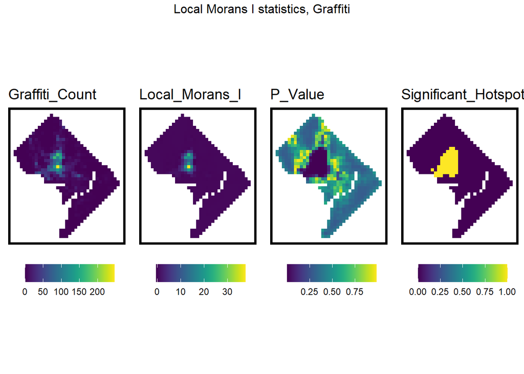

```r
## This is just for plotting
vars <- unique(final_net.localMorans$Variable)
varList <- list()

for(i in vars){
  varList[[i]] <-
    ggplot() +
      geom_sf(data = filter(final_net.localMorans, Variable == i),
              aes(fill = Value), colour=NA) +
      scale_fill_viridis(name="") +
      labs(title=i) +
      mapTheme(title_size = 14) + theme(legend.position="bottom")}

do.call(grid.arrange,c(varList, ncol = length(vars), top = "Local Morans I statistics, Graffiti"))
```

```r
# generates warning from NN
final_net <- final_net %>%
  mutate(graffiti.isSig =
           ifelse(local_morans[,5] <= 0.001, 1, 0)) %>%
  mutate(graffiti.isSig.dist =
           nn_function(st_c(st_coid(final_net)),
                       st_c(st_coid(filter(final_net,
                                           graffiti.isSig == 1))),
                       k = 1))
```

### Correlation Small Multiples

The figures below illustrate the correlation between the predictor variables and the dependent variable, graffiti complaints. The line of best fit is displayed in orange.

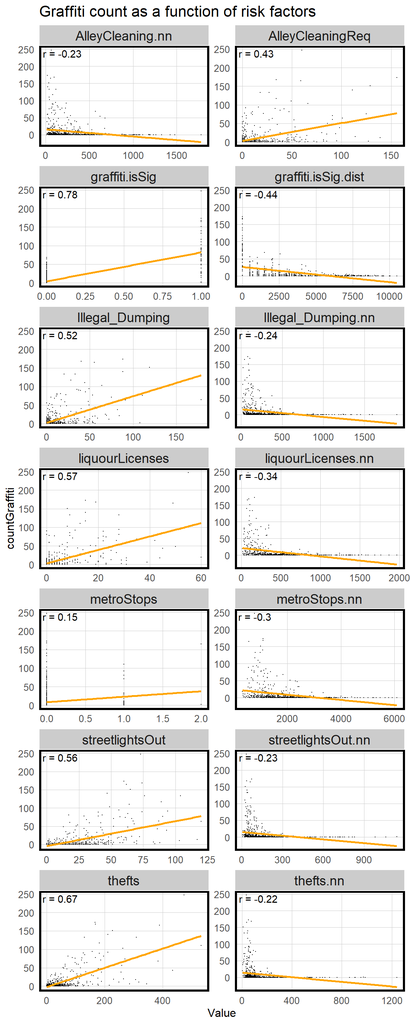

```r
correlation.long <-
  st_drop_geometry(final_net) %>%
    dplyr::select(-uniqueID, -cvID, -name, -District) %>%
    gather(Variable, Value, -countGraffiti)

correlation.cor <-
  correlation.long %>%
    group_by(Variable) %>%
    summarize(correlation = cor(Value, countGraffiti, use = "complete.obs"))

ggplot(correlation.long, aes(Value, countGraffiti)) +
  geom_point(size = 0.1) +
  geom_text(data = correlation.cor, aes(label = paste("r =", round(correlation, 2))),
            x=-Inf, y=Inf, vjust = 1.5, hjust = -.1) +
  geom_smooth(method = "lm", se = FALSE, colour = "orange") +
  facet_wrap(~Variable, ncol = 2, scales = "free") +
  labs(title = "Graffiti count as a function of risk factors") +
  plotTheme()
```

## Modeling and Cross-Validation

This chunk builds four models: 1. Random K-fold Cross Validation (CV) on just the risk factors 2. Random K-fold CV on risk factors and spatial process (significant areas of graffiti complaints) 3. Spatial leave-one-group-out (LOGO) CV on just risk factors 4. Spatial LOGO-CV on risk factors and spatial process

```r
## define the variables we want
# reg.vars <- c("Abandoned_Cars.nn", "Illegal_Dumping.nn",
#               "liquourLicenses.nn", "metroStops.nn", "streetlightsOut.nn", "thefts.nn")
#
# reg.ss.vars <- c("Abandoned_Cars.nn", "Illegal_Dumping.nn",
#                 "liquourLicenses.nn", "metroStops.nn", "streetlightsOut.nn", "thefts.nn",
#                 "graffiti.isSig", "graffiti.isSig.dist")
# WITHOUT ABANDONED CARS
reg.vars <- c("Illegal_Dumping.nn", "liquourLicenses.nn", "metroStops.nn", "streetlightsOut.nn", "thefts.nn")

reg.ss.vars <- c("Illegal_Dumping.nn", "liquourLicenses.nn", "metroStops.nn", "streetlightsOut.nn",
                 "thefts.nn", "graffiti.isSig", "graffiti.isSig.dist")

## RUN REGRESSIONS
reg.cv <- crossValidate(
  dataset = final_net,
  id = "cvID",
  dependentVariable = "countGraffiti",
  indVariables = reg.vars) %>%
    dplyr::select(cvID = cvID, countGraffiti, Prediction, geometry)

reg.ss.cv <- crossValidate(
  dataset = final_net,
  id = "cvID",
  dependentVariable = "countGraffiti",
  indVariables = reg.ss.vars) %>%
    dplyr::select(cvID = cvID, countGraffiti, Prediction, geometry)

reg.spatialCV <- crossValidate(
  dataset = final_net,
  id = "name",
  dependentVariable = "countGraffiti",
  indVariables = reg.vars) %>%
    dplyr::select(cvID = name, countGraffiti, Prediction, geometry)

reg.ss.spatialCV <- crossValidate(
  dataset = final_net,
  id = "name",
  dependentVariable = "countGraffiti",
  indVariables = reg.ss.vars) %>%
    dplyr::select(cvID = name, countGraffiti, Prediction, geometry)
```

```r
reg.summary <-
  rbind(
    mutate(reg.cv,           Error = Prediction - countGraffiti,
                             Regression = "Random k-fold CV: Just Risk Factors"),

    mutate(reg.ss.cv,        Error = Prediction - countGraffiti,
                             Regression = "Random k-fold CV: Spatial Process"),

    mutate(reg.spatialCV,    Error = Prediction - countGraffiti,
                             Regression = "Spatial LOGO-CV: Just Risk Factors"),

    mutate(reg.ss.spatialCV, Error = Prediction - countGraffiti,
                             Regression = "Spatial LOGO-CV: Spatial Process")) %>%
    st_sf()
```

### Model evaluation

To determine the effectiveness of our models, we have visualized the mean absolute errors (MAE) by each model. The models that include spatial process are generally better at predicting (smaller MAE) than those just predicting graffiti complaint locations using the risk factors. Our spatial LOGO-CV results contain higher MAE’s because that test is much more conservative than the random k-fold CV test [1].

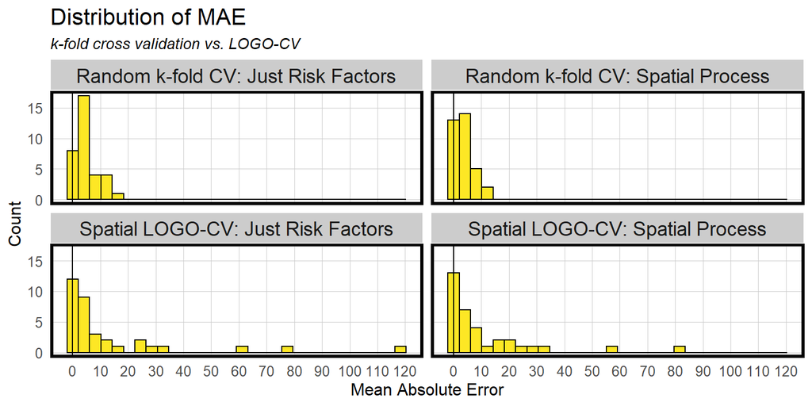

```r
# calculate errors by NEIGHBORHOOD
error_by_reg_and_fold <-
  reg.summary %>%
    group_by(Regression, cvID) %>%
    summarize(Mean_Error = mean(Prediction - countGraffiti, na.rm = T),
              MAE = mean(abs(Mean_Error), na.rm = T),
              SD_MAE = mean(abs(Mean_Error), na.rm = T)) %>%
  ungroup()

## plot histogram of OOF (out of fold) errors
error_by_reg_and_fold %>%
  ggplot(aes(MAE)) +
    geom_histogram(bins = 30, colour="black", fill = "#FDE725FF") +
    facet_wrap(~Regression) +
    geom_vline(xintercept = 0) + scale_x_continuous(breaks = seq(0, 120, by = 10)) +
    labs(title="Distribution of MAE", subtitle = "k-fold cross validation vs. LOGO-CV",
         x="Mean Absolute Error", y="Count") +
    plotTheme()
```

```r
cvtable <- st_drop_geometry(error_by_reg_and_fold) %>%
                group_by(Regression) %>%
                  summarize(Mean_MAE = round(mean(MAE), 2),
                            SD_MAE = round(sd(MAE), 2)) %>%
                kable() %>%
                  kable_styling("striped", full_width = F) %>%
                  row_spec(2, color = "black", background = "#FDE725FF") %>%
                  row_spec(4, color = "black", background = "#FDE725FF")

cvtable
```

| Regression | Mean_MAE | SD_MAE |
| --- | --- | --- |
| Random k-fold CV: Just Risk Factors | 4.83 | 4.09 |
| Random k-fold CV: Spatial Process | 3.40 | 3.03 |
| Spatial LOGO-CV: Just Risk Factors | 13.81 | 25.30 |
| Spatial LOGO-CV: Spatial Process | 11.06 | 17.57 |

## Testing Generalizability

### Neighborhood Context

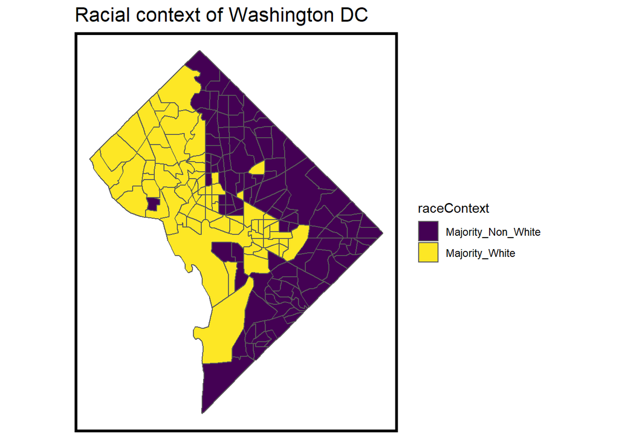

```r
census_var2017 <- c("B25026_001E", "B02001_002E", "B19013_001E", "B25058_001E", "B06012_002E")
tractsDC.17 <- get_acs(geography = "tract",
                           variables = census_var2017,
                           year=2017,
                           state=11999,
                           geometry=TRUE,
                           output="wide") %>%
    dplyr::select(-geometry, -B25026_001M, -B02001_002M, -B19013_001M, -B25058_001M, -B06012_002M) %>% # Remove margin of error columns
    st_transform(crs) %>%
  rename(TotalPop = B25026_001E,
             Whites = B02001_002E,
         MedHHInc = B19013_001E,
             MedRent = B25058_001E,
         TotalPoverty = B06012_002E) %>%
  #dplyr::select(-NAME, -starts_with("B")) %>%
  mutate(pctWhite = ifelse(TotalPop > 0, Whites / TotalPop,0),
         pctPoverty = ifelse(TotalPop > 0, TotalPoverty / TotalPop, 0),
         year = "2017") %>%
    mutate(pctWhite.scaled = pctWhite * 100,
                 pctPoverty.scaled = pctPoverty * 100,
                 raceContext = ifelse(pctWhite > .5, "Majority_White", "Majority_Non_White")) %>%
  dplyr::select(-Whites, -TotalPoverty, -NAME)

ggplot() +
  geom_sf(data = tractsDC.17, aes(fill = raceContext)) +
  scale_fill_viridis(discrete = TRUE) +
  labs(title = "Racial context of Washington DC") +
  mapTheme()
```

```r
reg.summary %>%
  filter(str_detect(Regression, "LOGO")) %>%
  st_centroid() %>%
  st_join(tractsDC.17) %>%
  na.omit() %>%
  st_drop_geometry() %>%
  group_by(Regression, raceContext) %>%
  summarize(mean.Error = mean(Error, na.rm = T)) %>%
  spread(raceContext, mean.Error) %>%
  kable(caption = "Mean error by neighborhood racial demographics") %>%
  kable_styling("striped", full_width = F)
```

[output not shown]